# Chapter 1

```r
    exp(coef(summary(houses.model2)))
```

```
##                 Estimate Std. Error      t value Pr(>|t|)
## (Intercept) 2.024937e+05   1.006394          Inf        1
## sqft        1.000399e+00   1.000003 5.899933e+61        1
```

The price increases by 1.000399 when the sqft increases by 1.

```
f. Are LLSR assumptions satisfied in Model 2? Why or why not?
```

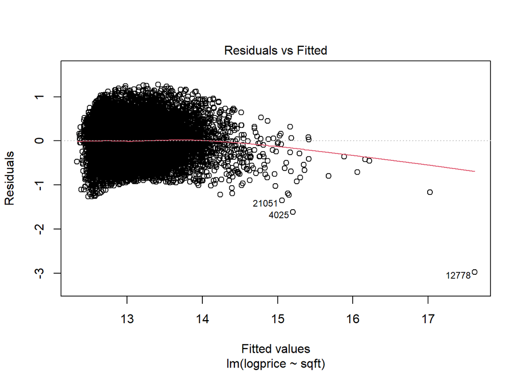

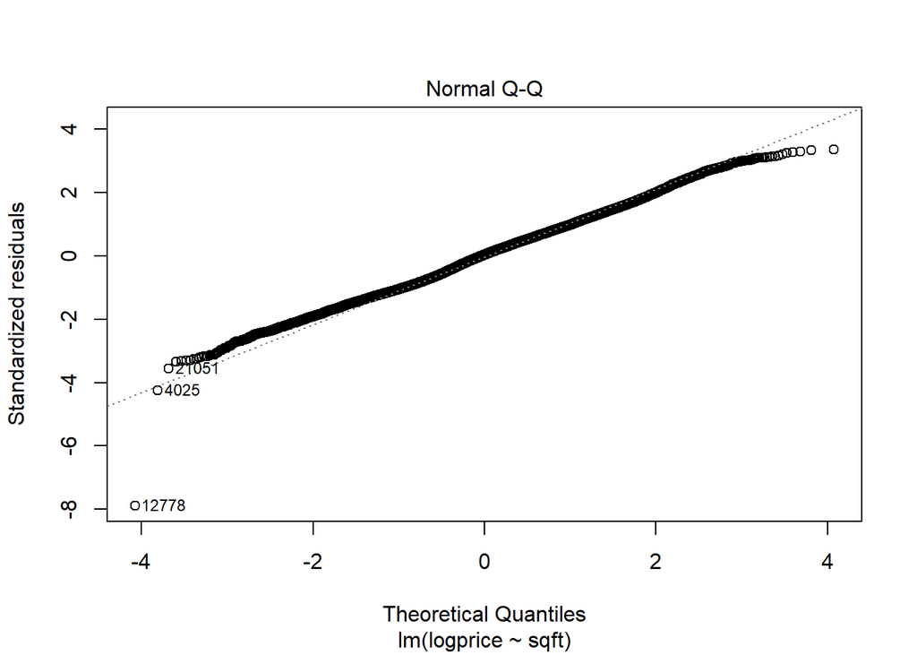

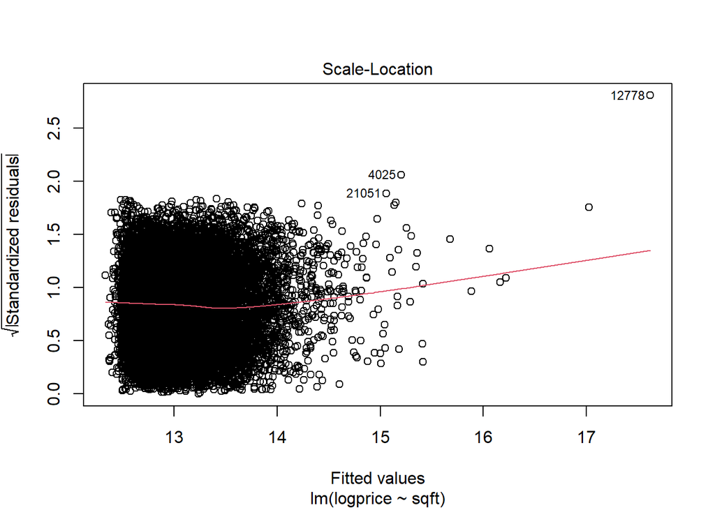

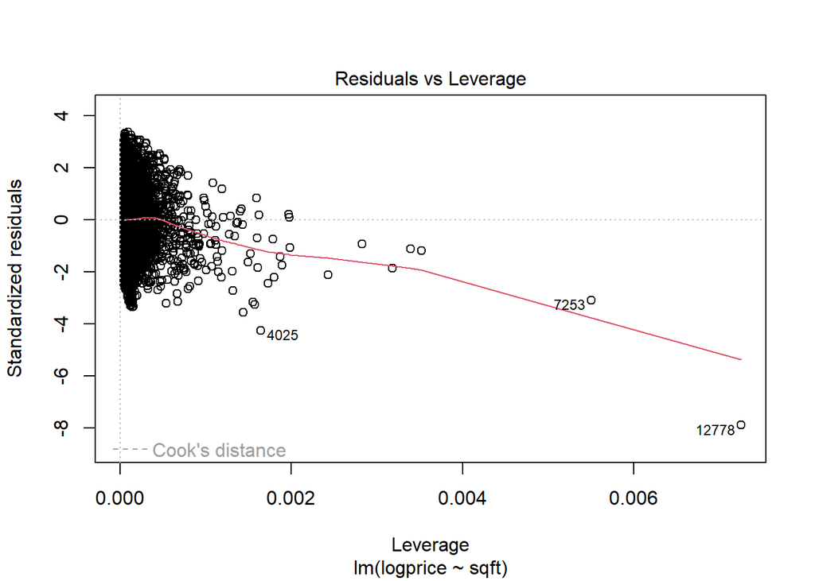

```r
plot(houses.model2)
```

Linearity: The residuals vs fitted plot shows that we do not pass the assumtion of linearity  
Independence: As long as houes are randomly sampled we pass the assumption of independence.  
Normallity: The Normal Q-Q graph looks roughly normal Equal Varience: No influential points in res vs levrage g. Create a new variable, `logsqft`, the natural log of `sqft`. Fit Model 3 where `price` and `logsqft` are the response and explanatory variables, respectively. Write out the regression line equation.

````
```r
houses <- houses %>%
  mutate(logsqft = log(sqft))
houses.model3 <- lm(price~logsqft, data=houses)
coef(summary(houses.model3))
```

```
##               Estimate Std. Error   t value Pr(>|t|)
## (Intercept) -3451377.1  35169.348 -98.13594        0
## logsqft       528647.5   4650.631 113.67221        0
```
````

price = −3451377.1 + 528647.5logsqft

```
h. How does predicted `price` change as `logsqft` increases by 1 in Model 3?
```

As logsqft increases by 1 price increases by 528647.5. i. How does predicted `price` change as `sqft` increases by 1%? As a hint, this is the same as multiplying `sqft` by 1.01.

```r
coef(summary(houses.model3))
```

```
##               Estimate Std. Error   t value Pr(>|t|)
## (Intercept) -3451377.1  35169.348 -98.13594        0
## logsqft       528647.5   4650.631 113.67221        0
```

```r
log(1.01) * 528647.5
```

```
## [1] 5260.218
```

As sqft increases by 1% price increases by 5260.218

```
j. Are LLSR assumptions satisfied in Model 3? Why or why not?
```

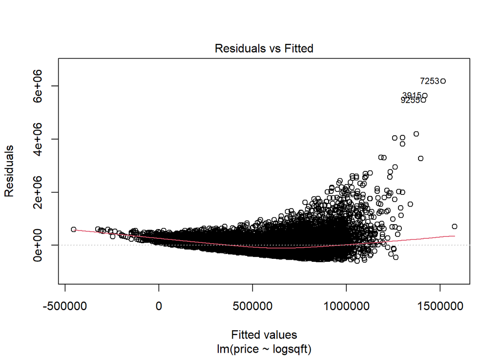

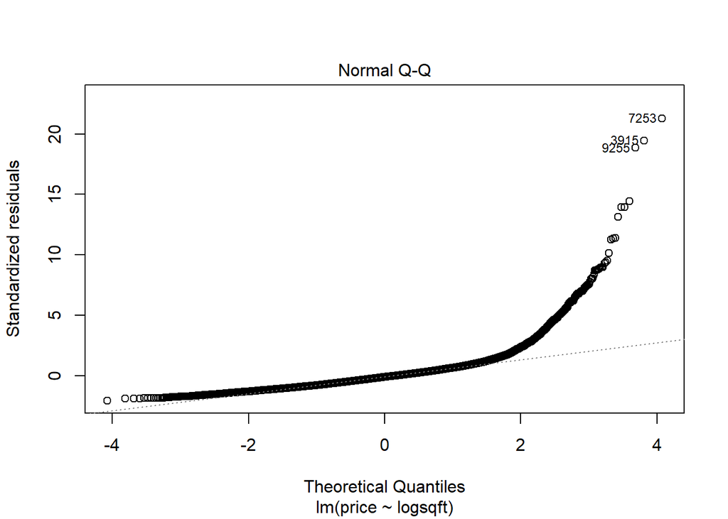

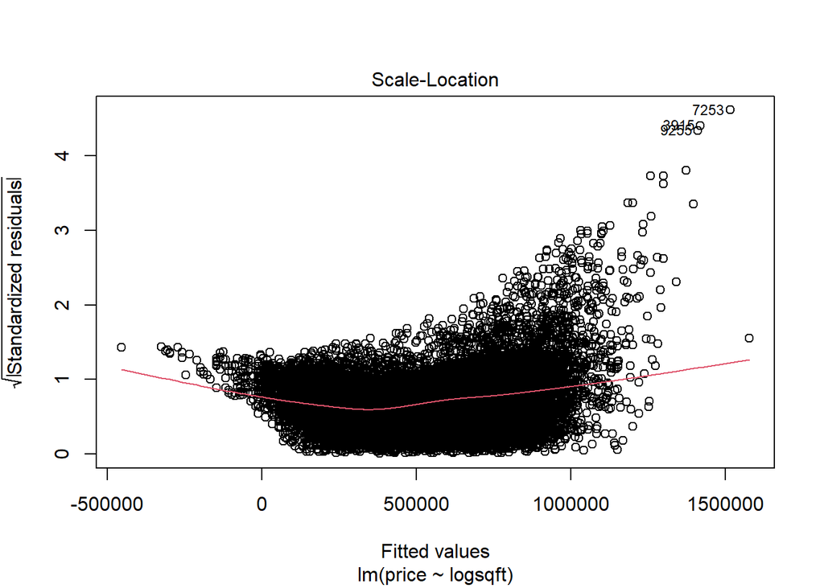

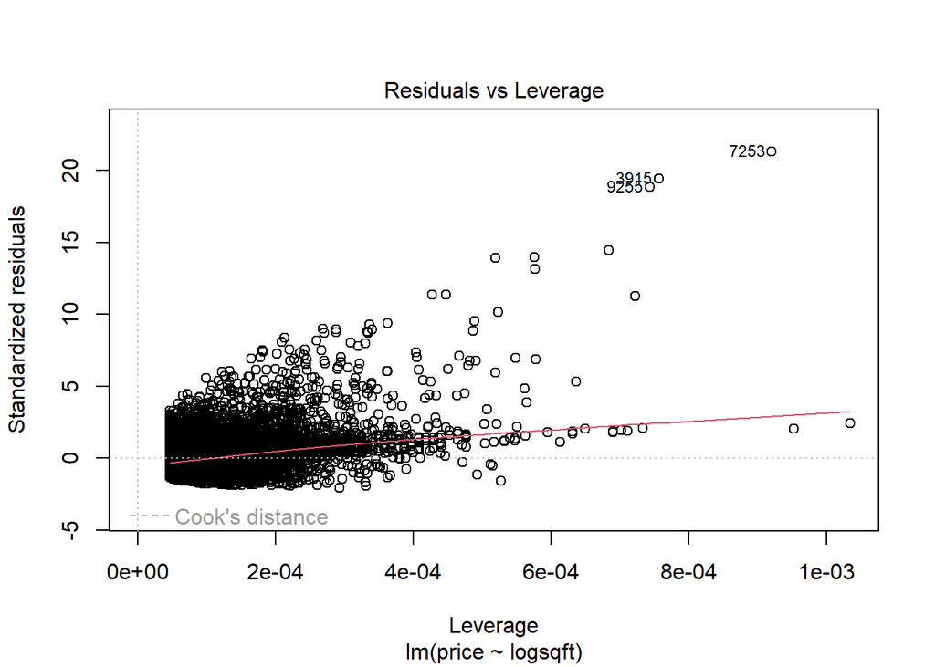

```r
plot(houses.model3)
```

Linearity: Massive curve in res vs fitted. Does not pass Indepdence: As long as houses are a random sample pass Normallity: Massive curve in normal Q-Q. Does not pass Equal Varience: No points of intrest in res vs levrage k. Fit Model 4, with `logsqft` and `logprice` as the response and explanatory variables, respectively. Write out the regression line equation.

```r
houses.model4 <- lm(logprice~logsqft, data=houses)
summary(houses.model4)
```

```
##
## Call:
## lm(formula = logprice ~ logsqft, data = houses)
##
## Residuals:
##      Min       1Q   Median       3Q      Max
## -1.10511 -0.29300  0.01262  0.25701  1.33011
##
## Coefficients:
##             Estimate Std. Error t value Pr(>|t|)
## (Intercept) 6.729916   0.047062   143.0   <2e-16 ***
## logsqft     0.836771   0.006223   134.5   <2e-16 ***
## ---
## Signif. codes:  0 '***' 0.001 '**' 0.01 '*' 0.05 '.' 0.1 ' ' 1
##
## Residual standard error: 0.3886 on 21611 degrees of freedom
## Multiple R-squared:  0.4555, Adjusted R-squared:  0.4555
## F-statistic: 1.808e+04 on 1 and 21611 DF,  p-value: < 2.2e-16
```

logprice = 6.7299 + 0.8368logsqft

```
l. In Model 4, what is the effect on `price` corresponding to a 1\% increase in `sqft`?
```

```r
coef(summary(houses.model4))
```

```
##             Estimate  Std. Error  t value Pr(>|t|)
## (Intercept) 6.729916 0.047061982 143.0011        0
## logsqft     0.836771 0.006223257 134.4587        0
```

```r
exp(log(1.01) * 0.836771)
```

```
## [1] 1.008361
```

1.008361

```
m. Are LLSR assumptions satisfied in Model 4? Why or why not?
```

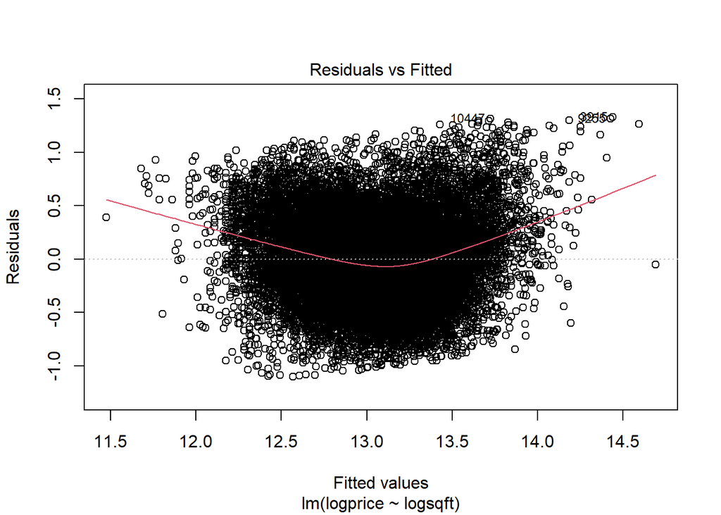

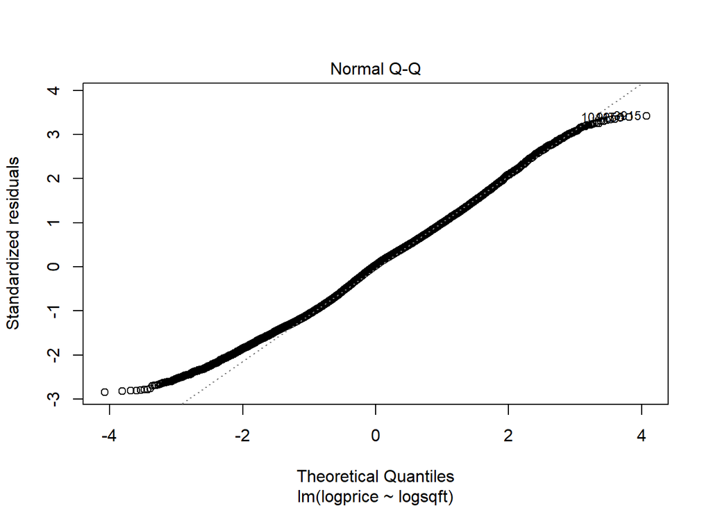

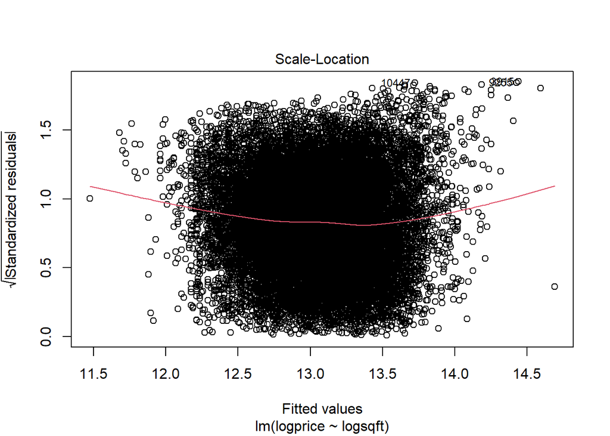

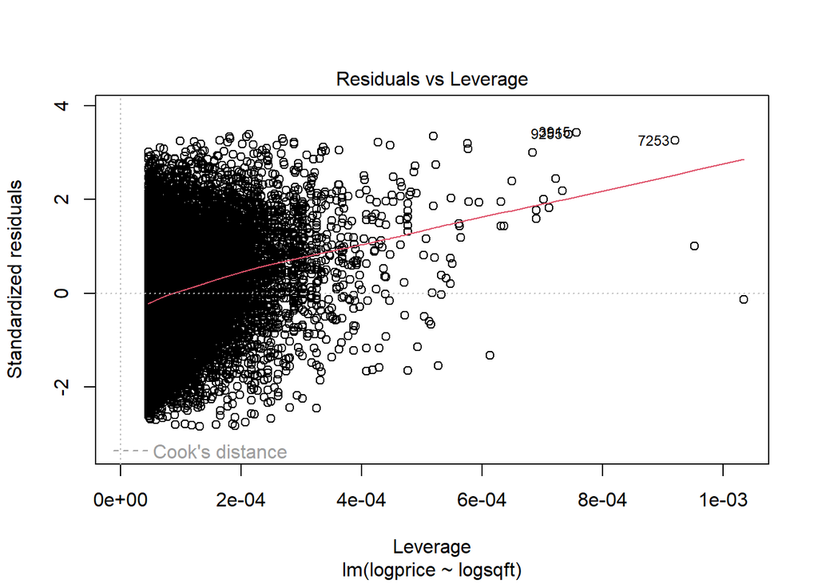

```r
plot(houses.model4)
```

```
n. Find another explanatory variable which can be added to Model 4 to create a model with a higher adjusted $R^2$ value. Interpret the coefficient of this added variable.
```

```r
houses.finalmodel <- lm(logprice~logsqft+bedrooms, data=houses)
summary(houses.finalmodel)
```

```
##
## Call:
## lm(formula = logprice ~ logsqft + bedrooms, data = houses)
##
## Residuals:
##      Min       1Q   Median       3Q      Max
## -1.14609 -0.28684  0.01003  0.25464  2.53108
##
## Coefficients:
##              Estimate Std. Error t value Pr(>|t|)
## (Intercept)  6.250597   0.052832  118.31   <2e-16 ***
## logsqft      0.931302   0.007871  118.32   <2e-16 ***
## bedrooms    -0.069544   0.003595  -19.34   <2e-16 ***
## ---
## Signif. codes:  0 '***' 0.001 '**' 0.01 '*' 0.05 '.' 0.1 ' ' 1
##
## Residual standard error: 0.3853 on 21610 degrees of freedom
## Multiple R-squared:  0.4648, Adjusted R-squared:  0.4647
## F-statistic:  9383 on 2 and 21610 DF,  p-value: < 2.2e-16
```

```
Adding in Bedrooms increase adj r^2 from .4555 to .4647. For every extra bedroom the logprice  decreases by .0695
```

### Open-Ended Exercises

1. **The Bechdel Test.** In April, 2014, website FiveThirtyEight published the article, “The Dollar-And-Cents Case Against Hollywood’s Exclusion of Women” [@Hickey2014]. There, they analyze returns on investment for 1,615 films released between 1990 and 2013 based on the Bechdel test. The test, developed by cartoonist Alison Bechdel, measures gender bias in films by checking if a film meets three criteria:
   - there are at least two named women in the picture
   - they have a conversation with each other at some point
   - that conversation isn’t about a male character

While the test is not a perfect metric of gender bias, data from it does  
allow for statistical analysis. In the FiveThirtyEight article, they  
find that, “passing the Bechdel test had no effect on the film’s return  
on investment.” Their data can be found in `bechdel.csv`. Key  
variables include:

- `year` = the year the film premiered
- `pass` = 1 if the film passes the Bechdel test, 0 otherwise
- `budget` = budget in 2013 U.S. dollars
- `totalGross` = total gross earnings in 2013 U.S. dollars
- `domGross` = domestic gross earnings in 2013 U.S. dollars
- `intGross` = international gross earnings in 2013 U.S. dollars
- `totalROI` = total return on investment (total gross divided by budget)
- `domROI` = domestic return on investment
- `intROI` = international return on investment

With this in mind, carry out your own analysis. Does passing the Bechdel  
test have any effect on a film’s return on investment?

```r
films <- read.csv("data/bechdel.csv")
films <- na.omit(films)
```

```r
#Not looking at intgross domgross introi domroi as they prob correlate with totals
cor(subset(films, select=c(pass, year, budget, totalGross, totalROI)))
```

```
##                    pass         year      budget  totalGross     totalROI
## pass        1.000000000 -0.002051994 -0.16822855 -0.07912535 -0.003087652
## year       -0.002051994  1.000000000  0.02829512 -0.04733561 -0.059964882
## budget     -0.168228552  0.028295116  1.00000000  0.69342330 -0.106452062
## totalGross -0.079125353 -0.047335609  0.69342330  1.00000000  0.059249281
## totalROI   -0.003087652 -0.059964882 -0.10645206  0.05924928  1.000000000
```

```r
# Select relevant columns from your dataset
films <- films[c("totalROI", "year", "budget", "totalGross", "pass")]

# Loop through pairs of variables
for (i in 1:(ncol(films)-1)) {
  for (j in (i+1):ncol(films)) {

    # Calculate correlation between variables i and j
    correlation_test_ij <- cor.test(films[[i]], films[[j]])
    correlation_coefficient_ij <- correlation_test_ij$estimate
    r_squared_ij <- correlation_coefficient_ij^2

    cat("\nCorrelation between", names(films)[i], "and", names(films)[j], "is:", correlation_coefficient_ij)
    cat("\nR-squared:", r_squared_ij)

    # Check if i is not "totalROI"
    if (names(films)[i] != "totalROI") {
      # Calculate correlation and r^2 with the interaction term of i and j
      interaction_term <- films[[i]] * films[[j]]
      correlation_test_interaction <- cor.test(interaction_term, films$totalROI)
      correlation_coefficient_interaction <- correlation_test_interaction$estimate
      r_squared_interaction <- correlation_coefficient_interaction^2

      cat("\nInteraction Correlation between", names(films)[i], ":", names(films)[j], "and totalROI is:", correlation_coefficient_interaction)
      cat("\nInteraction R-squared:", r_squared_interaction)
    }
  }
}
```

```
##
## Correlation between totalROI and year is: -0.05996488
## R-squared: 0.003595787
## Correlation between totalROI and budget is: -0.1064521
## R-squared: 0.01133204
## Correlation between totalROI and totalGross is: 0.05924928
## R-squared: 0.003510477
## Correlation between totalROI and pass is: -0.003087652
## R-squared: 9.533596e-06
## Correlation between year and budget is: 0.02829512
## R-squared: 0.0008006136
```

```
##
## Interaction Correlation between year : budget and totalROI is: -0.08808624
## Interaction R-squared: 0.007759185
## Correlation between year and totalGross is: -0.04733561
## R-squared: 0.00224066
## Interaction Correlation between year : totalGross and totalROI is: 0.05907256
## Interaction R-squared: 0.003489567
## Correlation between year and pass is: -0.002051994
## R-squared: 4.210679e-06
## Interaction Correlation between year : pass and totalROI is: -0.00320332
## Interaction R-squared: 1.026126e-05
## Correlation between budget and totalGross is: 0.6934233
## R-squared: 0.4808359
## Interaction Correlation between budget : totalGross and totalROI is: -0.006160272
## Interaction R-squared: 3.794895e-05
## Correlation between budget and pass is: -0.1682286
## R-squared: 0.02830085
## Interaction Correlation between budget : pass and totalROI is: -0.04873997
## Interaction R-squared: 0.002375585
## Correlation between totalGross and pass is: -0.07912535
## R-squared: 0.006260822
## Interaction Correlation between totalGross : pass and totalROI is: 0.05881828
## Interaction R-squared: 0.00345959
```

```r
films.model1 <- lm(totalROI~pass, data=films)
summary(films.model1)
```

```
##
## Call:
## lm(formula = totalROI ~ pass, data = films)
##
## Residuals:
##    Min     1Q Median     3Q    Max
##  -5.27  -3.91  -2.65  -0.63 426.24
##
## Coefficients:
##             Estimate Std. Error t value Pr(>|t|)
## (Intercept)   5.2743     0.6462   8.162 6.62e-16 ***
## pass         -0.1170     0.9477  -0.123    0.902
## ---
## Signif. codes:  0 '***' 0.001 '**' 0.01 '*' 0.05 '.' 0.1 ' ' 1
##
## Residual standard error: 18.91 on 1598 degrees of freedom
## Multiple R-squared:  9.534e-06,  Adjusted R-squared:  -0.0006162
## F-statistic: 0.01523 on 1 and 1598 DF,  p-value: 0.9018
```

As seen previously the adj r sqrd is very small for this model. Pass is not a good predictor for TotalROI

```r
films.model2 <- lm(totalROI~totalGross + totalGross:pass + pass + budget, data=films)
summary(films.model2)
```

```
##
## Call:
## lm(formula = totalROI ~ totalGross + totalGross:pass + pass +
##     budget, data = films)
##
## Residuals:
##    Min     1Q Median     3Q    Max
## -33.64  -3.58  -2.02  -0.20 419.63
##
## Coefficients:
##                   Estimate Std. Error t value Pr(>|t|)
## (Intercept)      8.188e+00  8.909e-01   9.191   <2e-16 ***
## totalGross       1.717e-08  2.981e-09   5.761    1e-08 ***
## pass            -1.885e+00  1.146e+00  -1.644    0.100
## budget          -9.745e-08  1.160e-08  -8.400   <2e-16 ***
## totalGross:pass  3.811e-09  3.629e-09   1.050    0.294
## ---
## Signif. codes:  0 '***' 0.001 '**' 0.01 '*' 0.05 '.' 0.1 ' ' 1
##
## Residual standard error: 18.47 on 1595 degrees of freedom
## Multiple R-squared:  0.04706,    Adjusted R-squared:  0.04467
## F-statistic: 19.69 on 4 and 1595 DF,  p-value: 7.749e-16
```

```r
films.model3 <- lm(totalROI~totalGross + totalGross:pass + budget, data=films)
summary(films.model3)
```

```
##
## Call:
## lm(formula = totalROI ~ totalGross + totalGross:pass + budget,
##     data = films)
##
## Residuals:
##    Min     1Q Median     3Q    Max
## -28.62  -3.55  -2.12  -0.19 420.31
##
## Coefficients:
##                   Estimate Std. Error t value Pr(>|t|)
## (Intercept)      7.211e+00  6.640e-01  10.861  < 2e-16 ***
## totalGross       1.854e-08  2.863e-09   6.477 1.25e-10 ***
## budget          -9.560e-08  1.155e-08  -8.275 2.68e-16 ***
## totalGross:pass  4.018e-10  2.980e-09   0.135    0.893
## ---
## Signif. codes:  0 '***' 0.001 '**' 0.01 '*' 0.05 '.' 0.1 ' ' 1
##
## Residual standard error: 18.48 on 1596 degrees of freedom
## Multiple R-squared:  0.04545,    Adjusted R-squared:  0.04365
## F-statistic: 25.33 on 3 and 1596 DF,  p-value: 5.222e-16
```

```r
films.model4 <- lm(totalROI~totalGross + pass + budget, data=films)
summary(films.model4)
```

```
##
## Call:
## lm(formula = totalROI ~ totalGross + pass + budget, data = films)
##
## Residuals:
##    Min     1Q Median     3Q    Max
## -27.22  -3.61  -2.08  -0.15 419.57
##
## Coefficients:
##               Estimate Std. Error t value Pr(>|t|)
## (Intercept)  7.877e+00  8.402e-01   9.376  < 2e-16 ***
## totalGross   1.890e-08  2.483e-09   7.612 4.59e-14 ***
## pass        -1.197e+00  9.407e-01  -1.272    0.203
## budget      -9.814e-08  1.158e-08  -8.473  < 2e-16 ***
## ---
## Signif. codes:  0 '***' 0.001 '**' 0.01 '*' 0.05 '.' 0.1 ' ' 1
##
## Residual standard error: 18.47 on 1596 degrees of freedom
## Multiple R-squared:  0.04641,    Adjusted R-squared:  0.04461
## F-statistic: 25.89 on 3 and 1596 DF,  p-value: 2.371e-16
```

```r
films.model5 <- lm(totalROI~totalGross + budget, data=films)
summary(films.model5)
```

```
##
## Call:
## lm(formula = totalROI ~ totalGross + budget, data = films)
##
## Residuals:
##    Min     1Q Median     3Q    Max
## -27.90  -3.55  -2.11  -0.18 420.26
##
## Coefficients:
##               Estimate Std. Error t value Pr(>|t|)
## (Intercept)  7.218e+00  6.617e-01  10.909  < 2e-16 ***
## totalGross   1.873e-08  2.480e-09   7.554 7.08e-14 ***
## budget      -9.582e-08  1.144e-08  -8.375  < 2e-16 ***
## ---
## Signif. codes:  0 '***' 0.001 '**' 0.01 '*' 0.05 '.' 0.1 ' ' 1
##
## Residual standard error: 18.48 on 1597 degrees of freedom
## Multiple R-squared:  0.04544,    Adjusted R-squared:  0.04424
## F-statistic: 38.01 on 2 and 1597 DF,  p-value: < 2.2e-16
```

As seen in the models 2-5 adj r^2 is highest for totalGross + totalGross:pass + pass + budget.

Still this model is not helpful in finding ROI. New parameters would be needed to accuractly model ROI.

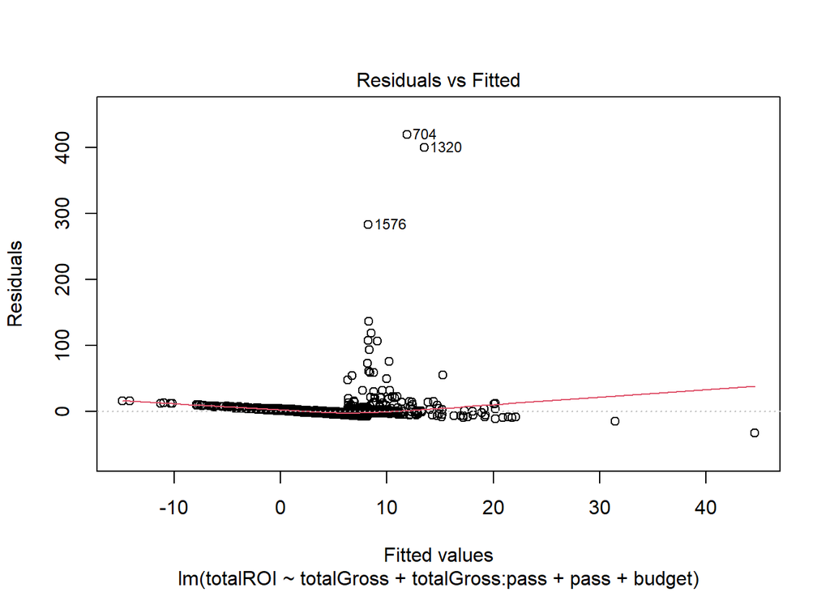

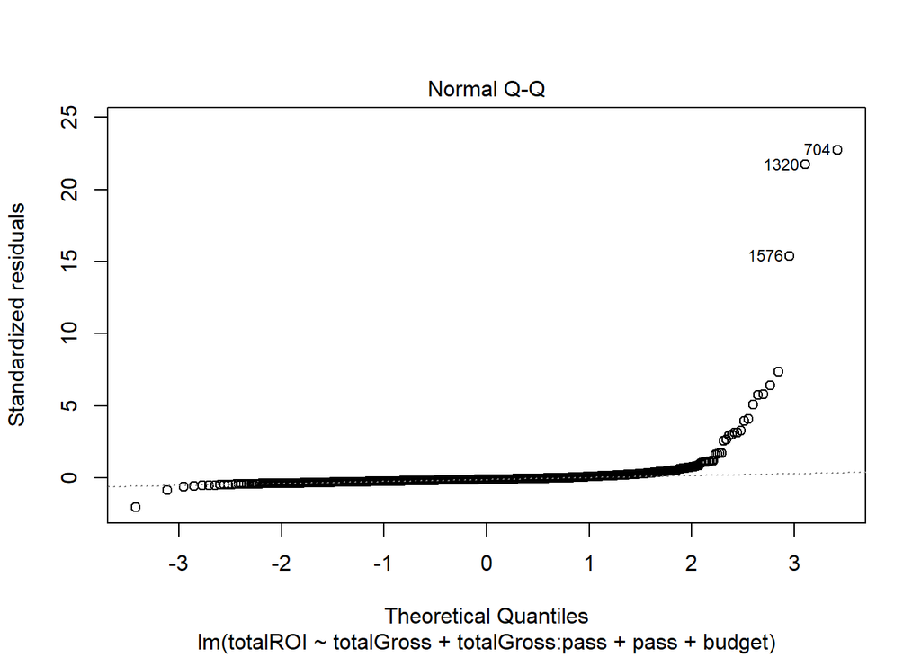

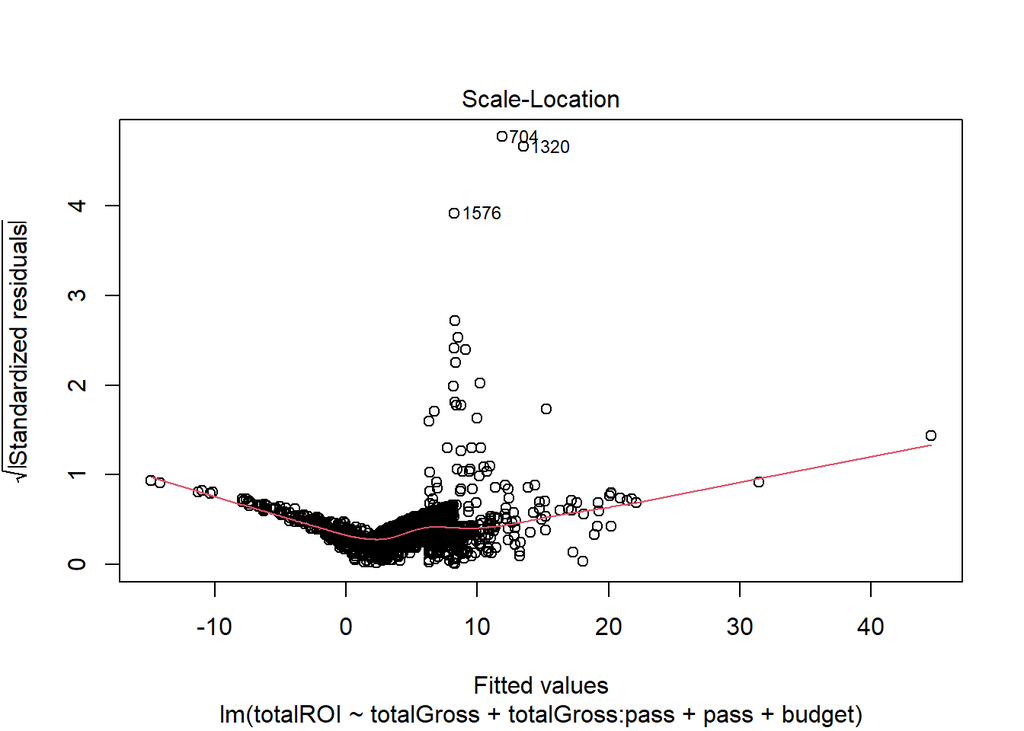

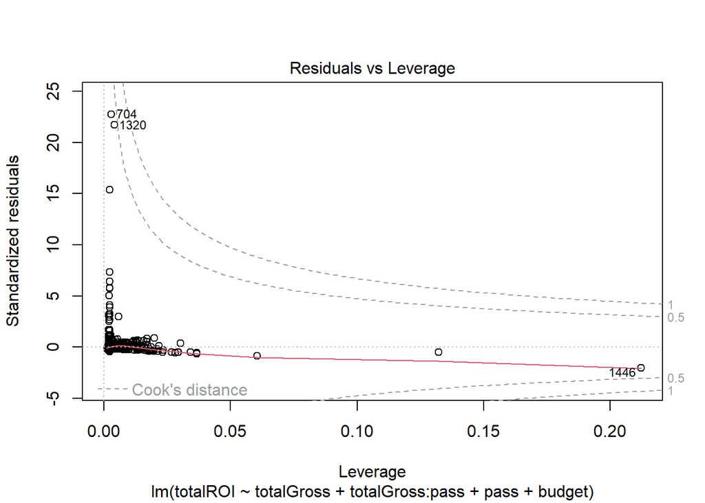

```r
plot(films.model2)
```

Line is not passed at all for this. Linearity: linearity is possibile but slight curve is seen. Indpendence: As long as movies are randomly sampled independence is pass Normallity: Normal Q-Q shows no normallity not pass Equal variance: Not pass

Only less than 5% of the data is ever explained by the model and the model does not pass LINE. The Bechdel test is not a good predictor for ROI in films. Other parameters would be needed to properly model ROI.

1. **Waitress tips.** A student collected data from a restaurant where she was a waitress [@Dahlquist2011]. The student was interested in learning under what conditions a waitress can expect the largest tips—for example: At dinner time or late at night? From younger or older patrons? From patrons receiving free meals? From patrons drinking alcohol? From patrons tipping with cash or credit? And should tip amount be measured as total dollar amount or as a percentage? Data can be found in `TipData.csv`. Here is a quick description of the variables collected:
   - `Day` = day of the week
   - `Meal` = time of day (Lunch, Dinner, Late Night)
   - `Payment` = how bill was paid (Credit, Cash, Credit with Cash tip)
   - `Party` = number of people in the party
   - `Age` = age category of person paying the bill (Yadult, Middle, SenCit)
   - `GiftCard` = was gift card used?
   - `Comps` = was part of the meal complimentary?
   - `Alcohol` = was alcohol purchased?
   - `Bday` = was a free birthday meal or treat given?
   - `Bill` = total size of the bill
   - `W.tip` = total amount paid (bill plus tip)
   - `Tip` = amount of the tip
   - `Tip.Percentage` = proportion of the bill represented by the tip